# sst_post_error_slowing

Steps:

- load file
- number each trial consecutively based on the onset time
- number the following trial for each trial
- merge the file with itself, merging each trial with its following trial
- for each measure the post-trial time for a correct result

This paper probably has a good method, ‘How to measure post-error slowing: A confound and a simple solution’,

Look at their “simple solution”, and follow the method there. https://www.sciencedirect.com/science/article/abs/pii/S0022249612000454 https://www.sciencedirect.com/science/article/pii/S0022249612000454

https://www.frontiersin.org/articles/10.3389/fpsyg.2014.00119/full

For the variables, see https://www.dropbox.com/scl/fi/acc3pmvb28b9swz0cnr82/Info-about-Stop-Signal-Task-Baseline-Analysis.docx?dl=0&rlkey=18mfzinj70pmuhdv8d00nh84e found in /Berkman Lab/Devaluation/Papers/Frontiers - Health Special Issue we should use: PostErrorSlowW1_mean PostErrorSlowW1_median not sst_pes_limited

## load file

```r
Sys.setenv(R_CONFIG_ACTIVE = Sys.info()["nodename"])
dropbox_file_dir = config::get("dev_analysis_data_dir")
sst_all_data_filepath <- "~/Dropbox (University of Oregon)/UO-SAN Lab/Berkman Lab/Devaluation/analysis_files/data/sst_behavioral_data_all.csv"

sst_all_data_raw <- readr::read_csv(sst_all_data_filepath)
```

```r
library(dplyr)
```

## About the Stop Signal Task

Task format The participant must respond to an arrow stimulus, by selecting one of two options, depending on the direction in which the arrow points. If an audio tone is present, the subject must withhold making that response (inhibition). The test consists of two parts: In the first part, the participant is introduced to the test and told to select the left-hand button when they see a left-pointing arrow and the right-hand button when they see a right-pointing arrow. There is one block of 16 trials for the participant to practice this. In the second part, the participant is told to continue selecting the buttons when they see the arrows but, if they hear an auditory signal (a beep), they should withhold their response and not select the button. Go task (e.g. press left when an arrow pointing to the left appears, and right when an arrow pointing to the right appears) Stop signal (e.g. a cross replacing the arrow OR a tone?) appears after a variable stop-signal delay (SSD), instructing participants to suppress the imminent go response.  
Conceptualizes the ability to inhibit the response as a race between a Go- and a Stop process that are triggered by the presentation of the Go and Stop-signal, respectively. If the Go process finishes first, the response will be executed. If the Stop process finishes first, the response will be inhibited (Teichert, 2015). Condition Type 1 CorrectGo (i.e. pressed left when an arrow pointing to the left appears, and right when an arrow pointing to the right appears) 2 FailedGo (i.e. did NOT press left when an arrow pointing to the left appears, and right when an arrow pointing to the right appears) 3 CorrectStop (i.e. Suppressed the go response) 4 FailedStop: (i.e. Failed to suppressed the go response)

## Load file with participant data

```r
# sst_all_data_raw <- read.csv(file = "https://www.dropbox.com/s/0gj8fcxa06peq29/sst_behavioral_data_all.3.7.22.csv?dl=1", stringsAsFactors = FALSE, header = TRUE) # dropbox > DEV > Health special issue >
# #Remove test trials
# sst_all_data_raw <- sst_all_data_raw[!grepl("DEV999", sst_all_data_raw$subid),]
```

## Calculating Post-Error Slowing

We will examine post-error slowing. This will be calculated by subtracting the reaction time (RT) preceding a Stop-error trial from the trial following it and averaging these across all stop errors (i.e. higher scores reflect higher post-error slowing, a measure of adaptive behavioral adjustment). ## Step 1: Number each trial (per wave) consecutively based on the onset time

```r
library(dplyr)
#View(sst_all_data_raw)
sst_all_data_raw <- sst_all_data_raw%>%group_by(subid,waveid,runid) %>% mutate(trial_id = seq_along(reaction_time))
```

## Step 2: And duration for previous and next trials. No longer needed with new approach

```r
# Subtract the RT preceeding a Stop-error trial ("FailedStop") from the trial following it
#library(dplyr)
#sst_all_data_raw <- mutate(sst_all_data_raw, previous_duration = lag(duration, 2))
#sst_all_data_raw <- mutate(sst_all_data_raw, next_duration = lead(duration, 2))
#do a lead and lag by trial type - only look at those surrounded by CorrectGo
#sst_all_data_raw <-  for (condition == "CorrectGo")
        #{mutate(sst_all_data_raw, previous_duration_limited = lag(duration, 2))}
#sst_all_data_raw <- mutate(sst_all_data_raw, next_duration_limited = ifelse(condition == "CorrectGo", lead(duration, 2)))
#sst_all_data_raw <- mutate(sst_all_data_raw, previous_duration_limited = lag(duration, 2, ifelse(condition == "CorrectGo")))
#library(tidyverse)
#sst_all_data_raw <- sst_all_data_raw %>%
        #mutate(
                #previous_duration_limited = if_else(lag(condition, 2) == "CorrectGo",
                       #lag(duration, 2))) %>%
  #fill(previous_duration_limited)
write.csv(sst_all_data_raw,paste0(dropbox_file_dir,"SST_Raw2.csv"), row.names = FALSE)
```

```r
#Create a column that returns a yes if the Correct Go comes after a Failed Stop
sst_all_data_raw$PostError_CorrectGo <- if_else( #If
    sst_all_data_raw$condition == "CorrectGo" #The condition is a Correct Go
    & sst_all_data_raw$waveid == "1" #and it is wave 1
    & lag(sst_all_data_raw$condition == "FailedStop", 2), # and the previous condition is a Failed Stop, (ignoring the Cue condition)
    "yes", "no" ) #label row "yes", otherwise, label it "no"
#Create a column that returns a yes if the Correct Go comes after a Correct Go
sst_all_data_raw$PostCorrect_CorrectGo <- if_else( #If
    sst_all_data_raw$condition == "CorrectGo" #The condition is a Correct Go
    & sst_all_data_raw$waveid == "1" #and it is wave 1
    & lag(sst_all_data_raw$condition == "CorrectGo", 2), # and the previous condition is a Correct Go, (ignoring the Cue condition)
    "yes", "no" ) #label row "yes", otherwise, label it "no"
```

##MEAN SCORES ## Calculate average response time for each participant for 1) the Correct Gos that follow Failed Stops

```r
#1 POST-ERROR CORRECT GO TRIALS
#Filter for only Correct Gos that are followed by Failed Stops
sst_PECGonly <- filter(sst_all_data_raw, PostError_CorrectGo == "yes") #PECG refers to Post-Error Correct Go trials
write.csv(sst_PECGonly,paste0(dropbox_file_dir, "SST_PEC.csv"), row.names = FALSE)
#Create a histogram to look for group of responses that reflect anticipatory responding (i.e. occur before reasonably possible to respond to the cue)
library(ggplot2)
psych::describe(sst_PECGonly$reaction_time)
```

|  | vars | n | mean | sd | median | trimmed | mad | min | max | range | skew | kurtosis | se |
| --- | --- | --- | --- | --- | --- | --- | --- | --- | --- | --- | --- | --- | --- |
| X1 | 1 | 2993 | 0.6 | 0.17 | 0.58 | 0.59 | 0.14 | 0 | 1 | 1 | -0.44 | 2.13 | 0 |

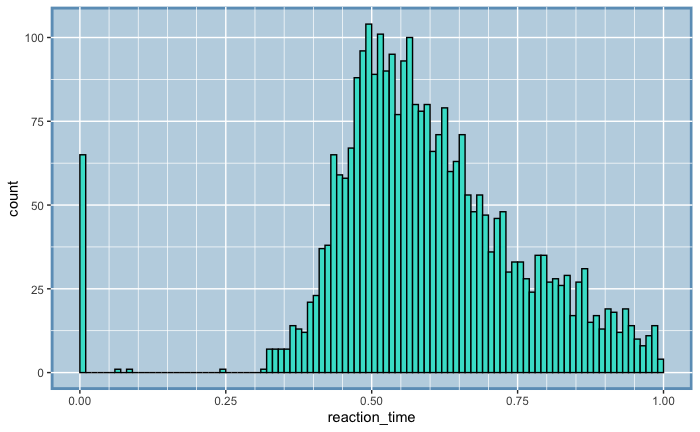

```r
ggplot(data = sst_PECGonly) +
  geom_histogram(aes(x = reaction_time), bins = 50, binwidth=.01 , boundary=-0.1, fill = 'turquoise', color = 'black', ) + theme(
    panel.background = element_rect(fill = "#BFD5E3", colour = "#6D9EC1",
                                size = 2, linetype = "solid"),
    panel.grid.major = element_line(size = 0.5, linetype = 'solid',
                                colour = "white"),
    panel.grid.minor = element_line(size = 0.25, linetype = 'solid',colour = "white")) +
 scale_x_continuous(minor_breaks = seq(.05, 10, .05))
```

```r
#Remove all rows where duration is less than 25 MS.
sst_PECGonly <- subset(sst_PECGonly, reaction_time>.25)
#Remove all rows where duration is greater than 1.25 MS.
sst_PECGonly <- subset(sst_PECGonly, reaction_time<1.25)
#Check that this occurred
psych::describe(sst_PECGonly$reaction_time) #looks good
```

|  | vars | n | mean | sd | median | trimmed | mad | min | max | range | skew | kurtosis | se |
| --- | --- | --- | --- | --- | --- | --- | --- | --- | --- | --- | --- | --- | --- |
| X1 | 1 | 2925 | 0.61 | 0.14 | 0.58 | 0.6 | 0.14 | 0.32 | 1 | 0.68 | 0.63 | -0.23 | 0 |

```r
#Calculate the mean by participant for all Post-Error Correct Gos
sst_PECG_byPp <- sst_PECGonly %>% group_by(subid) %>% summarise(PECG_mean = mean(reaction_time, na.rm=TRUE))
#2 POST-CORRECT CORRECT GO TRIALS
#Filter for only Correct Gos that are preceeded and followed by Correct Gos
sst_PCCGonly <- filter(sst_all_data_raw, PostCorrect_CorrectGo == "yes") #PCCG refers to Post-Correct Correct Go trials
library(ggplot2)
psych::describe(sst_PCCGonly$reaction_time)
```

|  | vars | n | mean | sd | median | trimmed | mad | min | max | range | skew | kurtosis | se |
| --- | --- | --- | --- | --- | --- | --- | --- | --- | --- | --- | --- | --- | --- |
| X1 | 1 | 19766 | 0.56 | 0.15 | 0.53 | 0.55 | 0.12 | 0 | 1 | 1 | 0.05 | 2.07 | 0 |

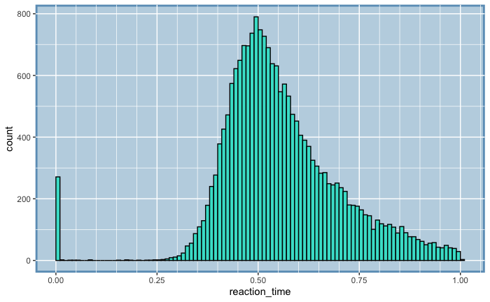

```r
ggplot(data = sst_PCCGonly) +
  geom_histogram(aes(x = reaction_time), bins = 50, binwidth=.01 , boundary=-0.1, fill = 'turquoise', color = 'black', ) + theme(
    panel.background = element_rect(fill = "#BFD5E3", colour = "#6D9EC1",
                                size = 2, linetype = "solid"),
    panel.grid.major = element_line(size = 0.5, linetype = 'solid',
                                colour = "white"),
    panel.grid.minor = element_line(size = 0.25, linetype = 'solid',colour = "white")) +
 scale_x_continuous(minor_breaks = seq(.05, 10, .05))
```

```r
#Remove all rows where duration is less than 25 MS.
sst_PCCGonly <- subset(sst_PCCGonly, reaction_time>.25)
#Remove all rows where duration is greater than 1.25 MS.
sst_PCCGonly <- subset(sst_PCCGonly, reaction_time<1.25)
#Check that this occurred
psych::describe(sst_PCCGonly$reaction_time) #looks good
```

|  | vars | n | mean | sd | median | trimmed | mad | min | max | range | skew | kurtosis | se |
| --- | --- | --- | --- | --- | --- | --- | --- | --- | --- | --- | --- | --- | --- |
| X1 | 1 | 19479 | 0.56 | 0.13 | 0.53 | 0.55 | 0.12 | 0.25 | 1 | 0.75 | 0.89 | 0.44 | 0 |

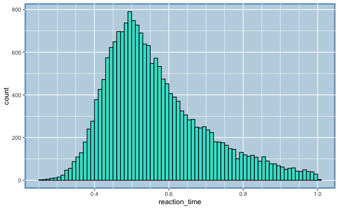

```r
ggplot(data = sst_PCCGonly) +
  geom_histogram(aes(x = reaction_time), bins = 50, binwidth=.01 , boundary=-0.1, fill = 'turquoise', color = 'black', ) + theme(
    panel.background = element_rect(fill = "#BFD5E3", colour = "#6D9EC1",
                                size = 2, linetype = "solid"),
    panel.grid.major = element_line(size = 0.5, linetype = 'solid',
                                colour = "white"),
    panel.grid.minor = element_line(size = 0.25, linetype = 'solid',colour = "white")) +
 scale_x_continuous(minor_breaks = seq(.05, 10, .05))
```